# HW 2: Types of Data

#### CPE232 Data Models

# Import Dependency

```python
import pandas as pd
import matplotlib.pyplot as plt
```

# Part 1 : Basic Python

## Task 1

Perform the following:

- Write a program to get input of different types from the user.
- Display type of each variable.
- Convert a variable of the type float to Integer.
- Demonstrate a comparison of before vs after the type conversion.

```python
# Input values from the user
string_value = input("Enter a string: ")
integer_value = int(input("Enter an integer: "))
float_value = float(input("Enter a float: "))
```

```python
# Display the data types
print(type(string_value))
print(type(integer_value))
print(type(float_value))
```

```
<class 'str'>
<class 'int'>
<class 'float'>
```

```python
# Convert integer to float and vice versa
convert_int_to_float = float(integer_value)
convert_float_to_int = int(float_value)
```

```python
# Show before and after convert float to int
print("Convert integer_value")
print("Before Convert: ",integer_value)
print("After Convert: ",convert_int_to_float)
print("Convert float_valie")
print("Before Convert: ",float_value)
print("After Convert: ",convert_float_to_int)
```

```
Convert integer_value
Before Convert:  12
After Convert:  12.0
Convert float_valie
Before Convert:  5.53
After Convert:  5
```

## Task 2

Given a dictionary of students with their scores, find the average score of each student across all subjects and identify the student with the highest average score.

```python
students_grades = {
    "John": [85, 90, 78],
    "Alice": [88, 92, 80],
    "Bob": [75, 85, 72],
    "Diana": [90, 95, 94],
    "Charlie": [70, 65, 80]
}
```

```python
# Calculate and print the average grade for each student
for key in students_grades:
    print(key,sum(students_grades[key])/len(students_grades[key]))
```

```
John 84.33333333333333
Alice 86.66666666666667
Bob 77.33333333333333
Diana 93.0
Charlie 71.66666666666667
```

```python
# Find the student with the highest average grade
mx = 0
mxSt = ""
for key in students_grades:
    avg = sum(students_grades[key])/len(students_grades[key])
    if avg > mx :
        mx = avg
        mxSt = key
print(mxSt)
```

```
Diana
```

# Part 2 : Working with CSV!

Add a new column to this CSV file named "Bonus," and calculate the bonus for employees in the Sales department as 10% of their MonthlyRate.

```python
# Load the CSV file
file_path = 'employee_data.csv'
df = pd.read_csv(file_path)
```

```python
df.head()
```

|  | Age | DailyRate | Department | EducationField | Gender | MaritalStatus | MonthlyRate | OverTime |
| --- | --- | --- | --- | --- | --- | --- | --- | --- |
| 0 | 41 | 1102 | Sales | Life Sciences | Female | Single | 19479 | Yes |
| 1 | 49 | 279 | Research & Development | Life Sciences | Male | Married | 24907 | No |
| 2 | 37 | 1373 | Research & Development | Other | Male | Single | 2396 | Yes |
| 3 | 33 | 1392 | Research & Development | Life Sciences | Female | Married | 23159 | Yes |
| 4 | 27 | 591 | Research & Development | Medical | Male | Married | 16632 | No |

```python
# Add new column call 'Bonus'
df["Bonus"] = 0
df.head()
```

|  | Age | DailyRate | Department | EducationField | Gender | MaritalStatus | MonthlyRate | OverTime | Bonus |
| --- | --- | --- | --- | --- | --- | --- | --- | --- | --- |
| 0 | 41 | 1102 | Sales | Life Sciences | Female | Single | 19479 | Yes | 0 |
| 1 | 49 | 279 | Research & Development | Life Sciences | Male | Married | 24907 | No | 0 |
| 2 | 37 | 1373 | Research & Development | Other | Male | Single | 2396 | Yes | 0 |
| 3 | 33 | 1392 | Research & Development | Life Sciences | Female | Married | 23159 | Yes | 0 |
| 4 | 27 | 591 | Research & Development | Medical | Male | Married | 16632 | No | 0 |

```python
# Calculate 10% of bonus into the 'Bonus' Column
df["Bonus"] = df["MonthlyRate"]/10
```

```python
# Print and show result
df
```

|  | Age | DailyRate | Department | EducationField | Gender | MaritalStatus | MonthlyRate | OverTime | Bonus |
| --- | --- | --- | --- | --- | --- | --- | --- | --- | --- |
| 0 | 41 | 1102 | Sales | Life Sciences | Female | Single | 19479 | Yes | 1947.9 |
| 1 | 49 | 279 | Research & Development | Life Sciences | Male | Married | 24907 | No | 2490.7 |
| 2 | 37 | 1373 | Research & Development | Other | Male | Single | 2396 | Yes | 239.6 |
| 3 | 33 | 1392 | Research & Development | Life Sciences | Female | Married | 23159 | Yes | 2315.9 |
| 4 | 27 | 591 | Research & Development | Medical | Male | Married | 16632 | No | 1663.2 |
| ... | ... | ... | ... | ... | ... | ... | ... | ... | ... |
| 1465 | 36 | 884 | Research & Development | Medical | Male | Married | 12290 | No | 1229.0 |
| 1466 | 39 | 613 | Research & Development | Medical | Male | Married | 21457 | No | 2145.7 |
| 1467 | 27 | 155 | Research & Development | Life Sciences | Male | Married | 5174 | Yes | 517.4 |
| 1468 | 49 | 1023 | Sales | Medical | Male | Married | 13243 | No | 1324.3 |
| 1469 | 34 | 628 | Research & Development | Medical | Male | Married | 10228 | No | 1022.8 |

1470 rows × 9 columns

```python
# Save the updated DataFrame back to a CSV file
df.to_csv("employee_data_update.csv")
```

# Part 3 : Working with Matplotlib

Plot a graph showing the average salary of employees in each department to compare the average salaries across departments.

```python
# Load CSV and create DataFrame
data = pd.read_csv('employee_data.csv')
df = pd.DataFrame(data)
```

```python
# Calculate average MonthlyRate by Department
chart_df = df.groupby("Department").agg({
    "MonthlyRate" : "mean"
})
chart_df
```

| Department | MonthlyRate |
| --- | --- |
| Human Resources | 13492.984127 |
| Research & Development | 14284.865765 |
| Sales | 14489.793722 |

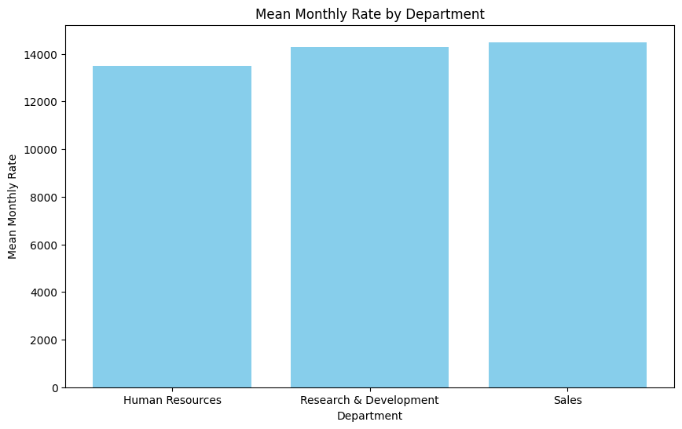

```python
# Plotting the bar chart
plt.figure(figsize=(10, 6))
plt.bar(chart_df.index, chart_df['MonthlyRate'], color='skyblue')
plt.xlabel('Department')
plt.ylabel('Mean Monthly Rate')
plt.title('Mean Monthly Rate by Department')
```

# Challenge!!! : Working with SATAN (Optional)

Great job, for not giving up on this subject!

[figure not shown]

Here’s the story: The CSV file that was given to you isn’t just an ordinary file -- it’s data from an organization where Alya-San works!

[figure not shown]

Alya feels that something suspicious is going on within the company. She suspects that there’s inequality in salaries between male and female employees.

She also wonders if the government might be intervening to encourage population growth by secretly increasing the salaries of married employees compared to those who are single.

Additionally, how much of a difference is there in salaries between employees who graduated from different fields of study?

Can you help Alya prove whether her suspicions are just in her head or if they’re actually true?

For Aria, everyone is truly **e q u a l**.

```python
# Implement code here
gender_rate_df = df.groupby("Gender").agg({
    "MonthlyRate" : "mean"
})
print("Average MonthlyRate by Gender")
gender_rate_df
```

```
Average MonthlyRate by Gender
```

| Gender | MonthlyRate |
| --- | --- |
| Female | 14674.600340 |
| Male | 14072.105442 |

```python
marriage_rate_df = df.groupby("MaritalStatus").agg({
    "MonthlyRate" : "mean"
})
print("Average MonthlyRate by Marital Status")
marriage_rate_df
```

```
Average MonthlyRate by Marital Status
```

| MaritalStatus | MonthlyRate |
| --- | --- |
| Divorced | 14310.085627 |
| Married | 14044.502229 |
| Single | 14699.817021 |

```python
study_rate_df = df.groupby("EducationField").agg({
    "MonthlyRate" : "mean"
})
print("Average MonthlyRate by EducationField")
study_rate_df
```

```
Average MonthlyRate by EducationField
```

| EducationField | MonthlyRate |
| --- | --- |
| Human Resources | 14810.740741 |
| Life Sciences | 14530.132013 |
| Marketing | 14076.943396 |
| Medical | 14295.056034 |
| Other | 13270.780488 |
| Technical Degree | 14210.363636 |

```python
rate_df = df.groupby(["Gender","MaritalStatus","EducationField"]).agg({
    "MonthlyRate" : "mean"
})
print("Average MonthlyRate each group")
rate_df
```

```
Average MonthlyRate each group
```

| Gender | MaritalStatus | EducationField | MonthlyRate |
| --- | --- | --- | --- |
| Female | Divorced | Human Resources | 10632.500000 |
|  |  | Life Sciences | 14908.863636 |
|  |  | Marketing | 10144.454545 |
|  |  | Medical | 16488.840909 |
|  |  | Other | 8053.200000 |
|  |  | Technical Degree | 10555.181818 |
|  | Married | Human Resources | 19303.000000 |
|  |  | Life Sciences | 14285.870370 |
|  |  | Marketing | 13711.078947 |
|  |  | Medical | 14600.024390 |
|  |  | Other | 15594.882353 |
|  |  | Technical Degree | 15733.363636 |
|  | Single | Human Resources | 13871.000000 |
|  |  | Life Sciences | 15580.602273 |
|  |  | Marketing | 14695.150000 |
|  |  | Medical | 14193.046875 |
|  |  | Other | 12789.857143 |
|  |  | Technical Degree | 16438.368421 |
| Male | Divorced | Human Resources | 13089.000000 |
|  |  | Life Sciences | 14571.855556 |
|  |  | Marketing | 14712.217391 |
|  |  | Medical | 14100.761905 |
|  |  | Other | 11243.142857 |
|  |  | Technical Degree | 16508.466667 |
|  | Married | Human Resources | 15274.692308 |
|  |  | Life Sciences | 13918.134969 |
|  |  | Marketing | 14980.743590 |
|  |  | Medical | 13145.515625 |
|  |  | Other | 13531.789474 |
|  |  | Technical Degree | 12612.435897 |
|  | Single | Human Resources | 4223.000000 |
|  |  | Life Sciences | 14647.610619 |
|  |  | Marketing | 13896.107143 |
|  |  | Medical | 14829.710843 |
|  |  | Other | 13939.400000 |
|  |  | Technical Degree | 13911.000000 |

Since Kobayashi-san will be reviewing your code, please present the data in a way that is clear and accurate. Otherwise, Kobayashi-san might fire you from the company!

[figure not shown]

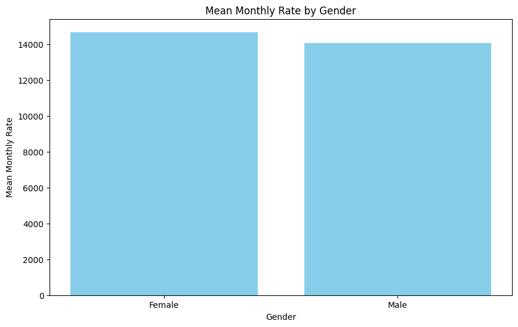

```python
# Write your code here
plt.figure(figsize=(10, 6))
plt.bar(gender_rate_df.index, gender_rate_df['MonthlyRate'], color='skyblue')
plt.xlabel('Gender')
plt.ylabel('Mean Monthly Rate')
plt.title('Mean Monthly Rate by Gender')
```

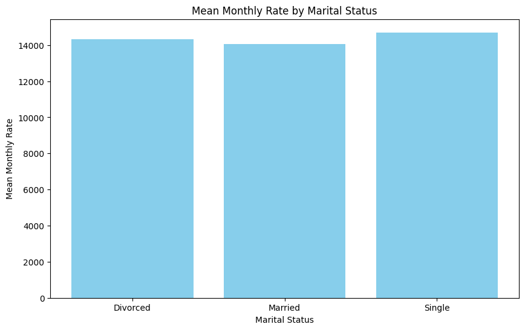

```python
plt.figure(figsize=(10, 6))
plt.bar(marriage_rate_df.index, marriage_rate_df['MonthlyRate'], color='skyblue')
plt.xlabel('Marital Status')
plt.ylabel('Mean Monthly Rate')
plt.title('Mean Monthly Rate by Marital Status')
```

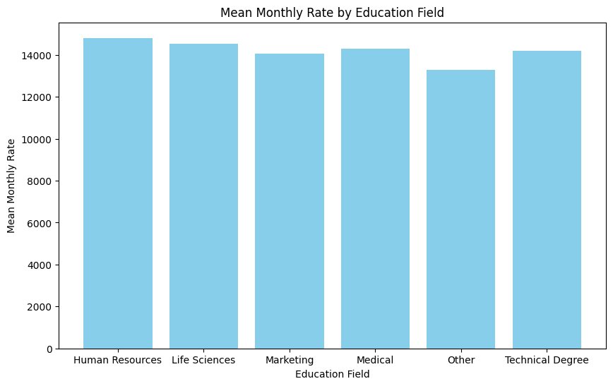

```python
plt.figure(figsize=(10, 6))
plt.bar(study_rate_df.index, study_rate_df['MonthlyRate'], color='skyblue')
plt.xlabel('Education Field')
plt.ylabel('Mean Monthly Rate')
plt.title('Mean Monthly Rate by Education Field')
```

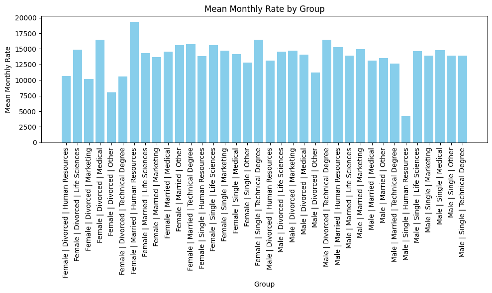

```python
plt.figure(figsize=(10, 6))

labels = [" | ".join(idx) for idx in rate_df.index]

plt.bar(labels, rate_df['MonthlyRate'], color='skyblue')

plt.xlabel('Group')
plt.ylabel('Mean Monthly Rate')
plt.title('Mean Monthly Rate by Group')

plt.xticks(rotation=90)

plt.tight_layout()
plt.show()
```